# ATR Analysis - ITQB

Adrianne Seiden

2026-07-31

# Overview

# Preparing data for analysis

## Importing DPT data

This code is modified from code by Stephany Soledad Chacon, “Box> Salk Institute Project> Salk Data> FTIR_Intact_decomposition_pots> FTIR_analysis.Rmd”. Using data in the DPT format, we can extrapolate sample attributes from the file names, then normalize and visualize spectra across replicates, crops, and treatments. The width of the line bounding the spectra represents the range of the data.

```r
# Check if folder exists and list files
if (!dir.exists(dpt_folder)) {
  stop("Directory does not exist: ", dpt_folder)
}

# List and sort files
cat("Files found in directory:\n")
```

```
#> Files found in directory:
```

```r
print(list.files(dpt_folder))
```

```
#>  [1] "AKS_suberin_miscanthus_H2O20_260629-0.dpt"
#>  [2] "AKS_suberin_miscanthus_H2O30_260629-0.dpt"
#>  [3] "AKS_suberin_miscanthus_H2Oinsol-milled_260716-0.dpt"
#>  [4] "AKS_suberin_miscanthus_H2Oinsol-milled_260716-1.dpt"
#>  [5] "AKS_suberin_miscanthus_NaOH20_260629-0.dpt"
#>  [6] "AKS_suberin_miscanthus_NaOH20_260629-1.dpt"
#>  [7] "AKS_suberin_miscanthus_NaOH30_260629-0.dpt"
#>  [8] "AKS_suberin_miscanthus_NaOH30_260629-1.dpt"
#>  [9] "AKS_suberin_miscanthus_raw-milled_260716-0.dpt"
#> [10] "AKS_suberin_miscanthus_raw_260629-0.dpt"
#> [11] "AKS_suberin_miscanthus_suberin-dark-precipitate_260729-0.dpt"
#> [12] "AKS_suberin_miscanthus_suberin-dark-precipitate_260729-1.0.dpt"
#> [13] "AKS_suberin_miscanthus_suberin-precipitate_260729-0.dpt"
#> [14] "AKS_suberin_miscanthus_suberin-precipitate_260729-1.dpt"
#> [15] "AKS_suberin_miscanthus_wsol-pour1_260723-0.dpt"
```

[output cut: 27 more lines]

```r
DPTfiles <- sort(list.files(dpt_folder, pattern = ".dpt"))
cat("Number of .dpt files:", length(DPTfiles), "\n")
```

```
#> Number of .dpt files: 42
```

```r
# Read files individually and combine
dpt_data_list <- list()

for (i in seq_along(DPTfiles)) {
  file_path <- file.path(dpt_folder, DPTfiles[i])

  # Read as lines and parse manually (DPT files are space-delimited)
  lines <- readLines(file_path, warn = FALSE)
  lines <- lines[lines != ""]  # Remove empty lines

  # Split each line by whitespace
  split_lines <- strsplit(lines, "\\s+")

  # Convert to data frame
  temp_data <- tryCatch({
    data.frame(
      wavenumber = as.numeric(sapply(split_lines, `[`, 1)),
      absorbance = as.numeric(sapply(split_lines, `[`, 2)),
      stringsAsFactors = FALSE
    )
  }, error = function(e) NULL)

  if (!is.null(temp_data)) {
    # Add filename column
    temp_data$filename <- DPTfiles[i]

    # Store in list
    dpt_data_list[[i]] <- temp_data
  }
}

# Remove NULL entries (failed reads)
dpt_data_list <- dpt_data_list[!sapply(dpt_data_list, is.null)]

# Combine all data
dpt_data <- bind_rows(dpt_data_list)

# Remove any rows with NA values
dpt_data <- dpt_data[complete.cases(dpt_data), ]

# Extract metadata from filenames

# Helper to extract fields from filenames with the pattern
# AKS_suberin_[plant]_[washing-treatment]_[yymmdd]-[run].dpt
extract_filename_fields <- function(filename) {
  stem <- tools::file_path_sans_ext(basename(filename))
  matches <- stringr::str_match(
    stem,
    "^AKS_suberin_([^_]+)_([^_]+)_([0-9]{6})-([0-9]+)$"
  )

  if (is.na(matches[1, 1])) {
    return(tibble(
      plant = NA_character_,
      method = NA_character_,
      run_date = as.Date(NA),
      run_rep = NA_integer_
    ))
  }

  tibble(
    plant = tolower(matches[1, 2]),
    method = tolower(matches[1, 3]),
    run_date = as.Date(matches[1, 4], format = "%y%m%d"),
    run_rep = as.integer(matches[1, 5])
  )
}

# Check for problems in filename parsing
bad_files <- dpt_data$filename[
  !stringr::str_detect(
    basename(dpt_data$filename),
    "^AKS_suberin_[^_]+_[^_]+_[0-9]{6}-[0-9]+\\.dpt$"
  )
]

bad_files
```

[output not shown]

[output cut: 1747 more lines]

```r
file_metadata <- bind_rows(lapply(dpt_data$filename, extract_filename_fields))
dpt_data <- bind_cols(dpt_data, file_metadata)

# save as csv for record-keeping
write.csv(dpt_data, file.path(outputs_folder, "dpt_data.csv"), row.names = FALSE)


cat("Samples by plant:\n")
```

```
#> Samples by plant:
```

```r
print(table( dpt_data$plant))
```

```
#>
#> miscanthus    sorghum  sugarcane
#>      33478      17620      21144
```

```r
cat("Samples by treatment:\n")
```

```
#> Samples by treatment:
```

```r
print(table( dpt_data$method))
```

```
#>
#>                    h2o20                    h2o30          h2oinsol-milled
#>                     1762                     1762                    10572
#>                   naoh20                   naoh30                      raw
#>                     3524                     3524                     7048
#>               raw-milled suberin-dark-precipitate      suberin-precipitate
#>                     7048                     1762                     3524
#>                     wsol                 wsol-1-2                 wsol-3-4
#>                     3524                     7048                     7048
#>                   wsol-5                 wsol-5-6               wsol-pour1
#>                     3524                     3524                     3524
#>               wsol-pour2
#>                     3524
```

### Preprocessing

Define color palettes for each plant and method combination. This will be used in the plots to maintain consistent coloring across different visualizations.

```r
# define color palettes for each plant and method combination
methods <- sort(unique( dpt_data$method))
plants <- sort(unique( dpt_data$plant))

plant_palette <- get_plant_palette(
  methods = methods,
  plants = plants
)

dpt_data$color_key <-
    paste(dpt_data$plant,
          dpt_data$method,
          sep = "_")

plant_colors <- get_plant_colors(sort(unique(dpt_data$plant)))
```

## Normalizing data

This code is modified to use baseline correction (subtracting the minimum) and standard normal variate (SNV) normalization.

```r
# Normalize absorbance data by sample (same approach as OPUSprocessing.Rmd)
dpt_data <- dpt_data %>%
  group_by(filename) %>%
  mutate(
    # Baseline correction - subtract minimum
    baseline_corrected = absorbance - min(absorbance, na.rm = TRUE),
    # Apply SNV (Standard Normal Variate) normalization
    mean_abs = mean(baseline_corrected, na.rm = TRUE),
    sd_abs = sd(baseline_corrected, na.rm = TRUE),
    normalized_absorbance = (baseline_corrected - mean_abs) / sd_abs
  ) %>%
  select(-mean_abs, -sd_abs) %>%
  ungroup()
dpt_data <- dpt_data %>%
  group_by(filename) %>%
  mutate(
    # Baseline correction - subtract minimum
    snv_corrected = normalized_absorbance - min(normalized_absorbance, na.rm = TRUE)
  ) %>%
  ungroup()

dpt_data <- dpt_data %>%
  mutate(
    material_class = unname(material_class_map[method]),
    extraction_bin = unname(extraction_bin_map[method]),
    material_class = factor(material_class, levels = c("raw", "insoluble", "soluble", "other")),
    extraction_bin = factor(extraction_bin, levels = c("wsol-1-2", "wsol-3-4", "wsol-5+", "wsol-pooled")),
    plot_group = as.character(material_class),
    plot_group = ifelse(material_class == "soluble", as.character(extraction_bin), plot_group),
    plot_group = factor(plot_group,
                         levels = c("raw", "insoluble", "wsol-1-2", "wsol-3-4", "wsol-5+", "wsol-pooled"))
  )

## Save normalized data for record-keeping

write.csv(dpt_data, file.path(outputs_folder, "dpt_data_normalized.csv"), row.names = FALSE)
```

# Plotting ATR spectra

## Plotting by preparation method

These plots are of normalized absorbance values. The thickness of the opaque line represents the range of the data. Annotations indicate integration regions used for calculations of simple plant, complex plant, carbonyl, protein/amide, and carbohydrate (“sugars”) organic matter proportions. Integration regions according to Mainka et al. (2022):

Mainka, M., Summerauer, L., Wasner, D., Garland, G., Griepentrog, M., Berhe, A. A., & Doetterl, S. (2022). Soil geochemistry as a driver of soil organic matter composition: Insights from a soil chronosequence. Biogeosciences, 19(6), 1675–1689. https://doi.org/10.5194/bg-19-1675-2022

Plus carbonyl region (1780 - 1690 cm<sup>-1</sup>) & sugars region (1200 - 900 cm<sup>-1</sup>) added to the analysis.

| Aliphatics (simple plant): | 2976 - 2898 cm<sup>-1</sup> + 2870 - 2839 cm<sup>-1</sup> |
| --- | --- |
| Carbonyls: | 1780 - 1690 cm<sup>-1</sup> |
| Protein/amide: | 1660 - 1580 cm<sup>-1</sup> |
| Aromatics (complex plant): | 1550 - 1500 cm<sup>-1</sup> |
| Sugars: | 1200 - 900 cm<sup>-1</sup> |

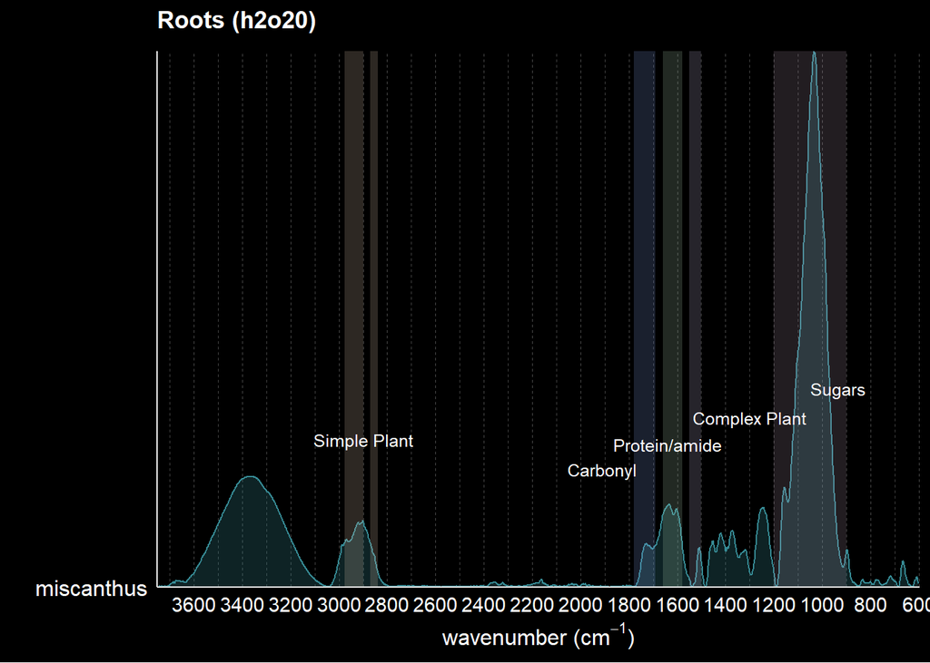

| h2o20 samples |
| --- |
| 1 miscanthus |

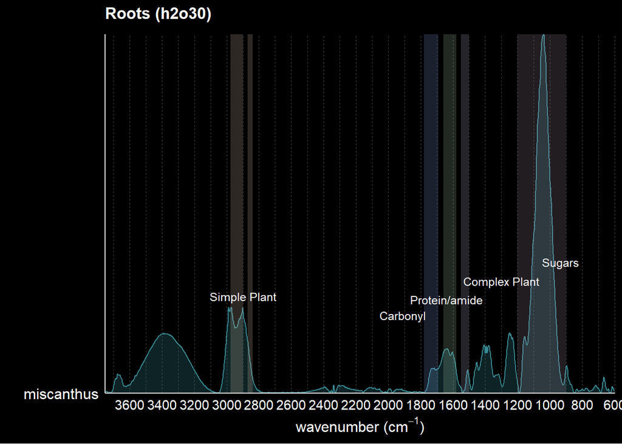

| h2o30 samples |
| --- |
| 1 miscanthus |

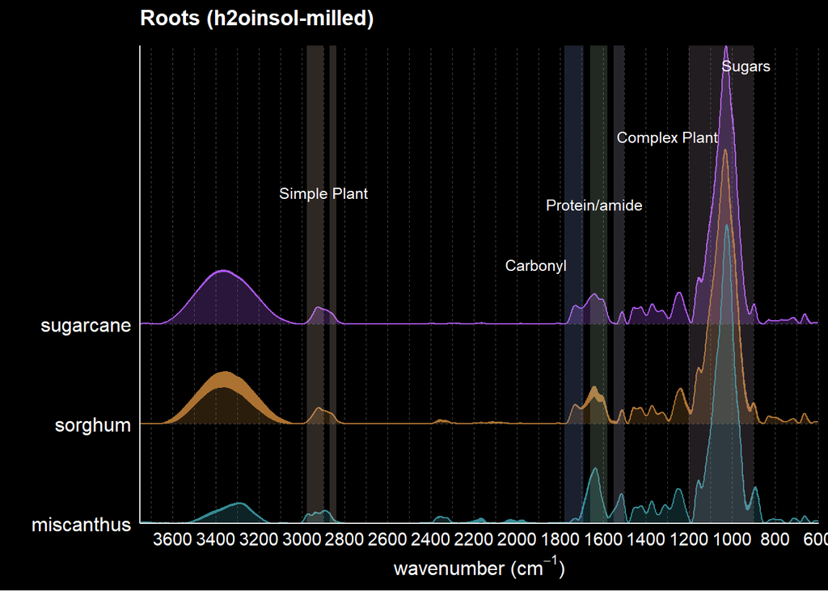

| h2oinsol-milled samples |
| --- |
| 2 miscanthus |
| 2 sorghum |
| 2 sugarcane |

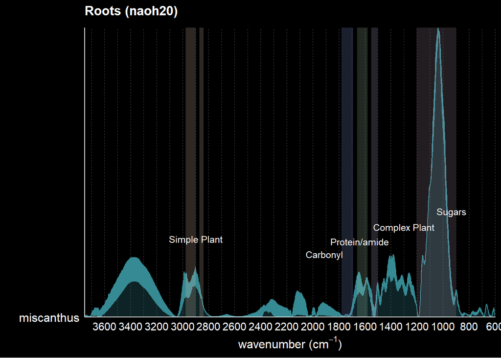

| naoh20 samples |
| --- |
| 2 miscanthus |

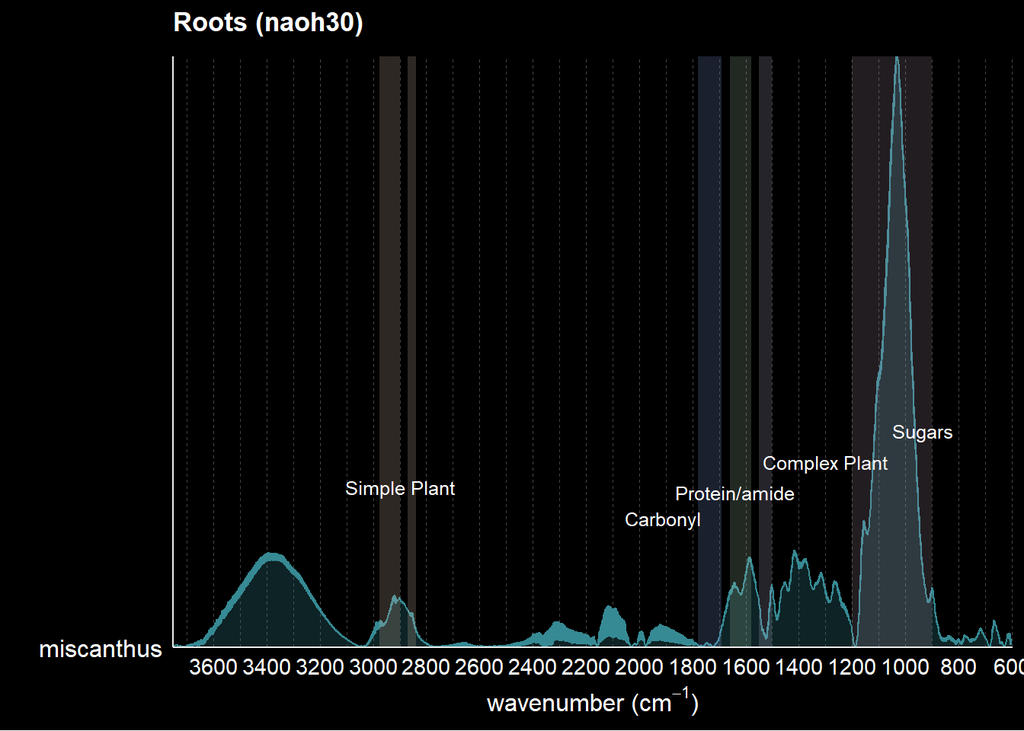

| naoh30 samples |
| --- |
| 2 miscanthus |

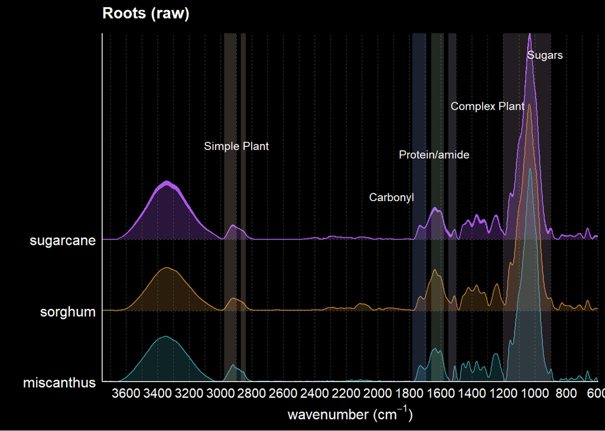

| raw samples |
| --- |
| 1 miscanthus |
| 1 sorghum |
| 2 sugarcane |

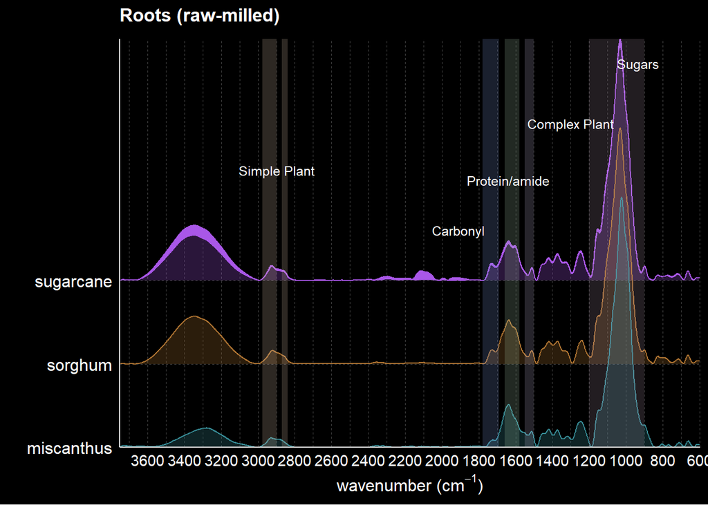

| raw-milled samples |
| --- |
| 1 miscanthus |
| 1 sorghum |
| 2 sugarcane |

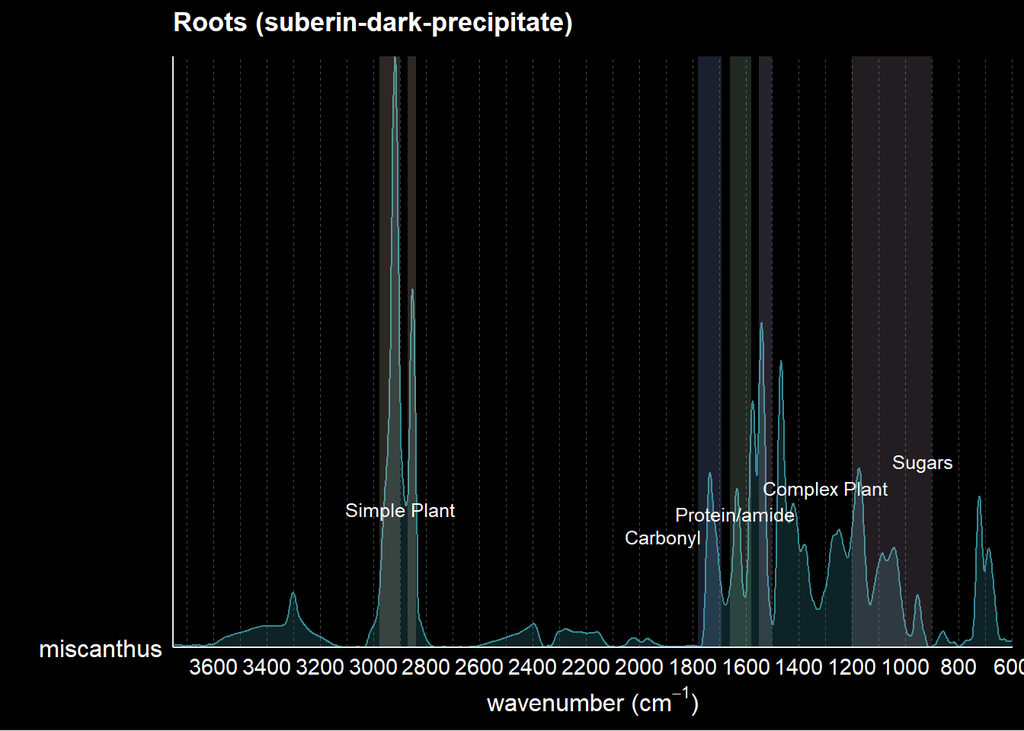

| suberin-dark-precipitate samples |
| --- |
| 1 miscanthus |

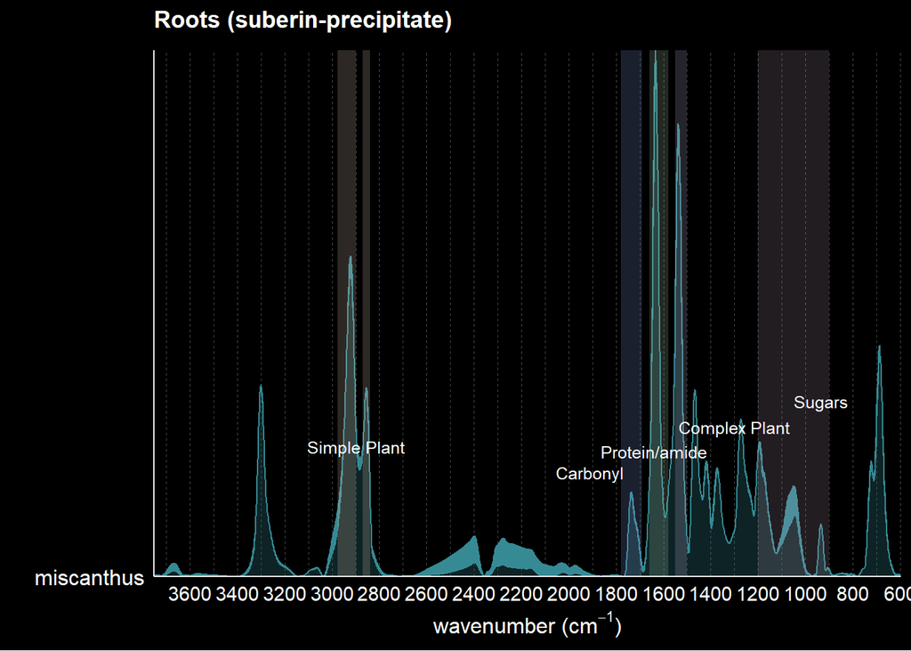

| suberin-precipitate samples |
| --- |
| 2 miscanthus |

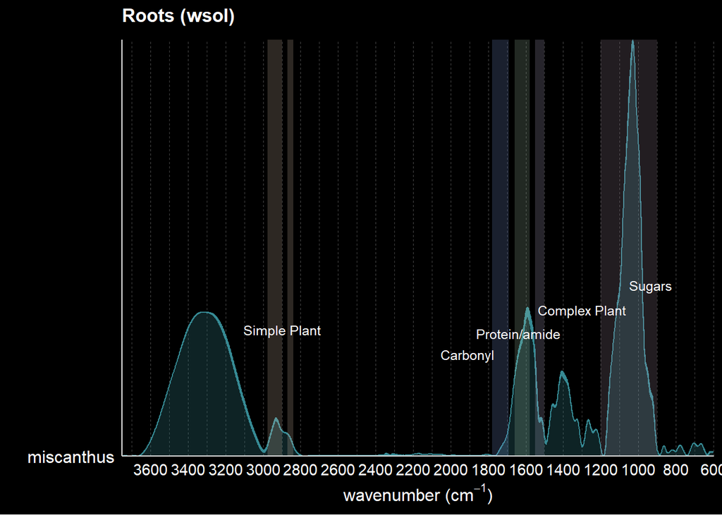

| wsol samples |
| --- |
| 2 miscanthus |

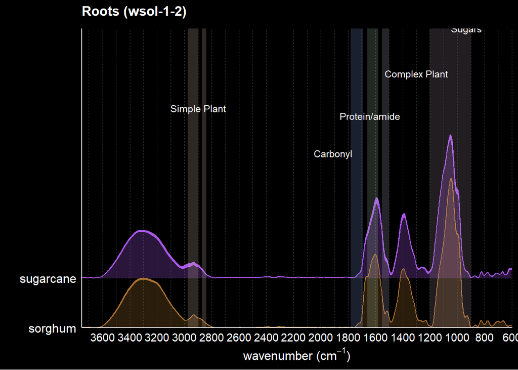

| wsol-1-2 samples |
| --- |
| 2 sorghum |
| 2 sugarcane |

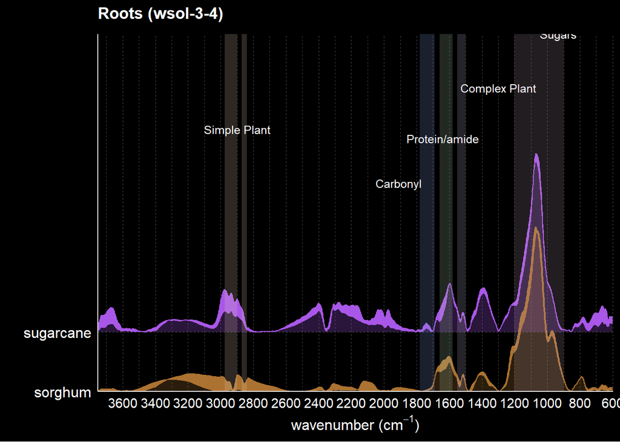

| wsol-3-4 samples |
| --- |
| 2 sorghum |
| 2 sugarcane |

[4 more figures not shown]

| wsol-pour2 samples |
| --- |
| 2 miscanthus |

```r
# Generic function to create ridge plots for any preparation method
create_method_ridge_plot <- function(data, target_method, title = NULL) {
  # Filter data for specific method
  filtered_data <- data %>%
    filter(method == target_method)

  # Create title if not provided
  if (is.null(title)) {
    title <- paste("Roots (", target_method, ")", sep = "")
  }

  # Determine y-position for annotations based on data
  present_levels <- sort(unique(filtered_data$plant))  # only levels actually in this week's data, in original order

  max_y <- 7 - length(present_levels)

  # Create the plot
  ridge_plot <- filtered_data %>%
    ggplot(mapping = aes(x = wavenumber,
                         y = plant,
                         height = snv_corrected,
                         group = plant,
                         fill = plant,
                         color = plant)) +
    geom_density_ridges(stat = "identity",
                        scale = 3, # overlap scale - 1 is no overlap, >1 is more overlap
                        alpha = 0.25) +

    scale_x_reverse(
      limits = c(3750, 600),
      breaks = seq(3600, 600, -200),  # Ticks every 200 from 3600 down to 600
      expand = c(0.001, 0.001)
      # Remove padding on x-axis
    ) +
    scale_y_discrete(expand = expansion(mult = c(0, 0.1), add = c(0, 0))) +  # space below, space above+  # space below, space above

    theme(axis.text.y = element_text(size = 12),
          legend.position = "none") +
    scale_fill_manual(values = plant_colors) +
    scale_color_manual(values = plant_colors) +
    ggtitle(title) +
    labs(x = expression("wavenumber (cm"^-1*")"), y = "") +
    # Add simple plant region annotation
    annotate("rect", xmin = 2976, xmax = 2898, ymin = -Inf, ymax = Inf,
             alpha = 0.2, fill = "#e3c8b1") +
    annotate("rect", xmin = 2870, xmax = 2839, ymin = -Inf, ymax = Inf,
             alpha = 0.2, fill = "#e3c8b1") +
    annotate("text", x = 2900, y = max_y * 1.08, label = "Simple Plant",
             size = 3.3, hjust = 0.5, color = annotation_text_color) +
    # Add carbonyl region annotation
    annotate("rect", xmin = 1780, xmax = 1690, ymin = -Inf, ymax = Inf,
             alpha = 0.2, fill = "#83a0e8") +
    annotate("text", x = 1910, y = max_y * 0.9, label = "Carbonyl",
             size = 3.3, hjust = 0.5, color = annotation_text_color) +
    # Add protein/amide region annotation
    annotate("rect", xmin = 1660, xmax = 1580, ymin = -Inf, ymax = Inf,
             alpha = 0.2, fill = "#a8cbad") +
    annotate("text", x = 1640, y = max_y * 1.05, label = "Protein/amide",
             size = 3.3, hjust = 0.5, color = annotation_text_color) +
    # Add complex plant region annotation
    annotate("rect", xmin = 1550, xmax = 1500, ymin = -Inf, ymax = Inf,
             alpha = 0.2, fill = "#beb5d5") +
    annotate("text", x = 1300, y = max_y * 1.22, label = "Complex Plant",
             size = 3.3, hjust = 0.5, color = annotation_text_color) +
    # Add sugars region annotation
    annotate("rect", xmin = 1200, xmax = 900, ymin = -Inf, ymax = Inf,
             alpha = 0.17, fill = "#c9aac4") +
    annotate("text", x = 933, y = max_y * 1.4, label = "Sugars",
             size = 3.3, hjust = 0.5, color = annotation_text_color)

  return(list(plot = ridge_plot, data = filtered_data))
}

# Generic function to create sample count tables
create_sample_count_table <- function(filtered_data, method) {
  col_name <- paste(method, "samples")

  counts <- filtered_data %>%
    select(filename, plant) %>%
    distinct() %>%
    count(plant) %>%
    mutate(!!col_name := paste(n, "&nbsp;&nbsp;", plant)) %>%
    select(all_of(col_name))

  return(counts)
}

# Create plots and tables for each method
methods <- sort(unique(dpt_data$method))

for (mt in methods) {
  # Create plot and get filtered data
  result <- create_method_ridge_plot(dpt_data, mt)

  # Print the plot
  print(result$plot)

  # Create and print sample count table with results='asis'
  counts_table <- create_sample_count_table(result$data, mt)
  cat(knitr::kable(counts_table, format = "html", escape = FALSE))
  cat("<br><br>")  # Add HTML line breaks for spacing
}
```

```r
# troubleshooting method colors
method_levels <- sort(unique(dpt_data$method))

if (!all(method_levels %in% names(method_colors))) {
  missing_colors <- setdiff(method_levels, names(method_colors))
  cat(missing_colors," do not have defined colors in method_colors.")
}
```

## Plotting by plant

These plots are of normalized absorbance values. The thickness of the opaque line represents the range of the data. Annotations indicate integration regions used for calculations of simple plant, complex plant, and protein/amide organic matter proportions.

| Aliphatics (simple plant): | 2976 - 2898 cm<sup>-1</sup> + 2870 - 2839 cm<sup>-1</sup> |
| --- | --- |
| Carbonyls: | 1780 - 1690 cm<sup>-1</sup> |
| Protein/Amide: | 1660 - 1580 cm<sup>-1</sup> |
| Aromatics (complex plant): | 1550 - 1500 cm<sup>-1</sup> |
| Sugars: | 1200 - 900 cm<sup>-1</sup> |

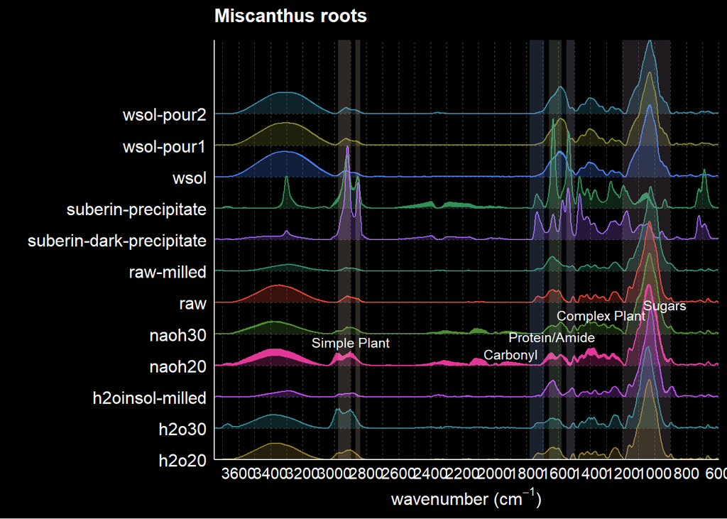

| miscanthus samples |
| --- |
| 1 h2o20 |
| 1 h2o30 |
| 2 h2oinsol-milled |
| 2 naoh20 |
| 2 naoh30 |
| 1 raw |
| 1 raw-milled |
| 1 suberin-dark-precipitate |
| 2 suberin-precipitate |
| 2 wsol |
| 2 wsol-pour1 |
| 2 wsol-pour2 |

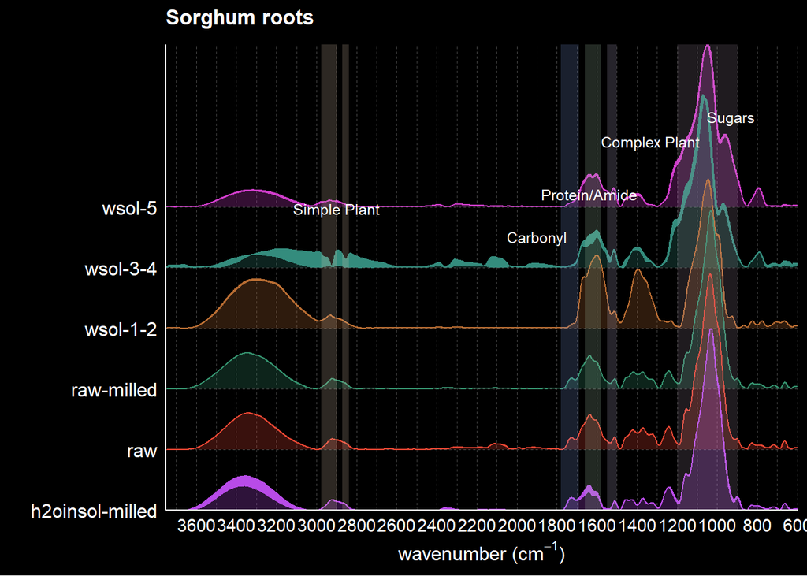

| sorghum samples |
| --- |
| 2 h2oinsol-milled |
| 1 raw |
| 1 raw-milled |
| 2 wsol-1-2 |
| 2 wsol-3-4 |
| 2 wsol-5 |

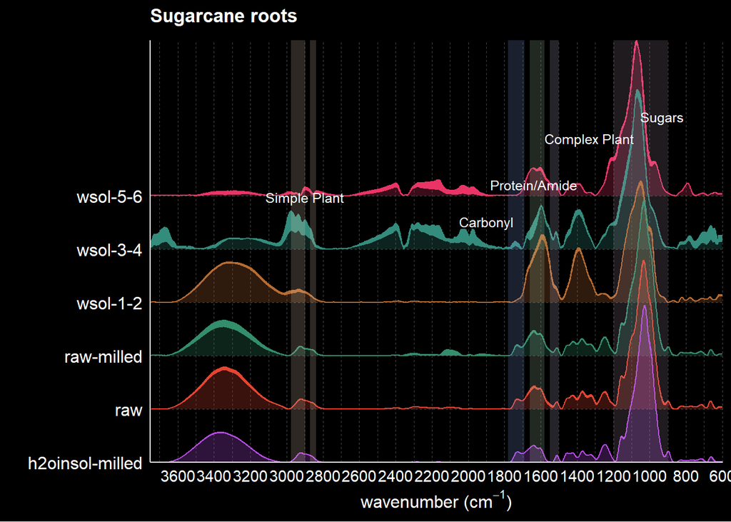

| sugarcane samples |
| --- |
| 2 h2oinsol-milled |
| 2 raw |
| 2 raw-milled |
| 2 wsol-1-2 |
| 2 wsol-3-4 |
| 2 wsol-5-6 |

```r
# check which methods do not have defined colors

# Generic function to create ridge plots for any preparation method
create_plant_faceted_plot <- function(data, current_plant, title = NULL) {
  # Filter data for specific method
  filtered_data <- data %>%
    filter(plant == current_plant)

  # Create title if not provided
  if (is.null(title)) {
    title <- paste(str_to_title(current_plant), "roots", sep = " ")
  }

  # Determine y-position for annotations based on data
  present_levels <- sort(unique(filtered_data$method))  # only levels actually in this week's data, in original order

  max_y <- 7 - length(present_levels)/5

  # Fixed method colors (from ITQB_color_config.R) -- method is now the hue,
  # not a shade of this plant's hue, so a given method is always the same
  # color here no matter which plant it's shown for.
  method_colors_current <- get_method_colors(present_levels)

  # Create the plot
  ridge_plot <- filtered_data %>%
    ggplot(mapping = aes(x = wavenumber,
                         y = method,
                         height = snv_corrected,
                         group = method,
                         fill = method,
                         color = method)) +
    geom_density_ridges(stat = "identity",
                        scale = 3, # overlap scale - 1 is no overlap, >1 is more overlap
                        alpha = 0.25) +
   scale_x_reverse(
      limits = c(3750, 600),
      breaks = seq(3600, 600, -200),  # Ticks every 200 from 3600 down to 600
      expand = c(0.001, 0.001)
      # Remove padding on x-axis
    ) +
    scale_y_discrete(expand = expansion(mult = c(0, 0.1), add = c(0, 0))) +  # space below, space above+  # space below, space above

    theme(axis.text.y = element_text(size = 12),
          legend.position = "none") +
    scale_fill_manual(values = method_colors_current) +
    scale_color_manual(values = method_colors_current) +
    ggtitle(title) +
    labs(x = expression("wavenumber (cm"^-1*")"), y = "") +
    # Add simple plant region annotation
    annotate("rect", xmin = 2976, xmax = 2898, ymin = -Inf, ymax = Inf,
             alpha = 0.2, fill = "#e3c8b1") +
    annotate("rect", xmin = 2870, xmax = 2839, ymin = -Inf, ymax = Inf,
             alpha = 0.2, fill = "#e3c8b1") +
    annotate("text", x = 2900, y = max_y*1.03, label = "Simple Plant",
             size = 3.33, hjust = 0.5, color = annotation_text_color) +
    # Add carbonyl region annotation
    annotate("rect", xmin = 1780, xmax = 1690, ymin = -Inf, ymax = Inf,
             alpha = 0.2, fill = "#83a0e8") +
    annotate("text", x = 1900, y = max_y*0.95, label = "Carbonyl",
             size = 3.33, hjust = 0.5, color = annotation_text_color) +
    # Add protein/amide region annotation
    annotate("rect", xmin = 1660, xmax = 1580, ymin = -Inf, ymax = Inf,
             alpha = 0.2, fill = "#a8cbad") +
    annotate("text", x = 1640, y = max_y * 1.07, label = "Protein/Amide",
             size = 3.33, hjust = 0.5, color = annotation_text_color) +
    # Add complex plant region annotation
    annotate("rect", xmin = 1550, xmax = 1500, ymin = -Inf, ymax = Inf,
             alpha = 0.2, fill = "#beb5d5") +
    annotate("text", x = 1333, y = max_y * 1.22, label = "Complex Plant",
             size = 3.33, hjust = 0.5, color = annotation_text_color) +
      # Add sugars region annotation
    annotate("rect", xmin = 1200, xmax = 900, ymin = -Inf, ymax = Inf,
             alpha = 0.16, fill = "#c3aac1") +
    annotate("text", x = 933, y = max_y * 1.29, label = "Sugars",
             size = 3.3, hjust = 0.5, color = annotation_text_color)
  return(list(plot = ridge_plot, data = filtered_data))
}

# Generic function to create sample count tables
create_sample_count_table <- function(filtered_data, plant_name) {
  col_name <- paste(plant_name, "samples")

  counts <- filtered_data %>%
    select(filename, method) %>%
    distinct() %>%
    count(method) %>%
    mutate(!!col_name := paste(n, "&nbsp;&nbsp;", method)) %>%
    select(all_of(col_name))

  return(counts)
}

# Create plots and tables for each plant
plants <- sort(unique(dpt_data$plant))

for (pt in plants) {
  # Create plot and get filtered data
  result <- create_plant_faceted_plot(dpt_data, pt)

  # Print the plot
  print(result$plot)

  # Create and print sample count table with results='asis'
  counts_table <- create_sample_count_table(result$data, pt)
  cat(knitr::kable(counts_table, format = "html", escape = FALSE))
  cat("<br><br>")  # Add HTML line breaks for spacing
}
```

### Create helper function for stacked range plots

```r
# Suberin-associated peak positions (wavenumber, cm^-1) and the color used to
# mark each one. Kept together as ONE data frame (rather than two separate
# vectors of numbers and colors) so a wavenumber and its color can never end
# up mismatched if someone later adds, removes, or reorders a peak -- each
# row is a single (position, color) pair that travels together.
# Used only by the precipitate plot (annotation_type = "peaks" below).
suberin_peak_positions <- data.frame(
  wavenumber = c(2923, 2853, # aliphatic C-H stretch
                  1739, 1712, # carbonyl C=O stretch
                  1635, 1603, # olefinics, ester-linked aromatics
                  1463, 1374, # methylene bending
                  1244, 1176, 1161, 722, # fingerprint
                  1600, 1510, 1030, 1050),  # contaminant peaks, lignin and sugars
  color = c("#e6ded6", "#e6ded6", # aliphatic C-H stretch
                 "#d1d9ec", "#d1d9ec", # carbonyl C=O stretch
                 "#dee8e0", "#dee8e0", # olefinics, ester-linked aromatics
                 "#eaeee6", "#eaeee6", # methylene bending
                 "#ece3ec", "#ece3ec", "#ece3ec", "#ece3ec", # fingerprint
                 "#ff4343", "#ff4343", "#ff4343", "#ff4343"), # contaminant peaks, lignin and sugars
  stringsAsFactors = FALSE
)

# Builds an "average + range" stacked overlay plot for an arbitrary set of plants.
#
# data:            dpt_data (or similar), filtered internally to `plants`
# plants:          character vector of plant names, bottom to top in the final plot
# methods_include: if supplied, ONLY these methods are kept (a short
#                  "allow-list" -- used for the precipitate plot, where it's
#                  easier to name the 3 methods you want than to exclude
#                  everything else). Takes priority over methods_exclude.
# methods_exclude: methods to drop before plotting (a "block-list" -- used
#                  for the main solubility-series plot). Ignored whenever
#                  methods_include is supplied, so a call never has to
#                  satisfy both rules at once.
# annotation_type: "regions" (default) shades the 5 functional-group
#                  integration windows, exactly as before. "peaks" instead
#                  draws dashed vertical lines at the suberin peak positions
#                  above -- use this for the precipitate plot.
build_stacked_range_plot <- function(data, plants, plant_palette,
                                      methods_include = NULL,
                                      methods_exclude = c("h2o20", "h2o30", "naoh20", "naoh30",
                                                           "raw", "suberin-precipitate",
                                                           "suberin-dark-precipitate"),
                                      annotation_type = c("regions", "peaks"),
                                      offset_amount = 2.8) {

  # match.arg() checks annotation_type against the two allowed values and
  # fills in "regions" if the argument is left out entirely. If you typo
  # something like "peak" (missing the s), this fails loudly right away
  # instead of quietly falling through to an `else` branch you didn't mean.
  annotation_type <- match.arg(annotation_type)

  plot_data <- data %>%
    filter(plant %in% plants)

  # Apply exactly ONE of the two filtering rules -- an include-list (keep
  # only these) or an exclude-list (drop these) -- never both, so there's
  # always one unambiguous set of methods per call.
  if (!is.null(methods_include)) {
    plot_data <- plot_data %>% filter(method %in% methods_include)
  } else {
    plot_data <- plot_data %>% filter(!method %in% methods_exclude)
  }

  plot_data <- plot_data %>%
    mutate(plant = factor(plant, levels = plants)) %>%
    mutate(snv_corrected = as.numeric(snv_corrected))

  # Calculate vertical offset for each plant to create stacking effect
  plant_offsets <- setNames(seq(0, length(plants) - 1) * offset_amount, plants)

  # Add offset to absorbance values based on plant
  plot_data <- plot_data %>%
    mutate(offset_absorbance = snv_corrected + plant_offsets[as.character(plant)])

  # Determine max y position for annotations
  max_y <- max(plot_data$offset_absorbance, na.rm = TRUE)

  # Create the base plot -- axes, theme, legend layout only. Functional-group
  # or peak annotations are added separately below, once we know which type
  # was asked for.
  #
  # CLEANUP NOTE: the original had TWO scale_x_reverse() calls stacked in the
  # same "+" chain (one with breaks starting at 4000, one at 3500). In
  # ggplot2, adding the same scale twice doesn't error and doesn't merge them
  # either -- the second one simply replaces the first. So the first call
  # here was dead code the whole time; only the second (kept below) was ever
  # actually controlling the axis. Removed the redundant one.
  plot_canvas <- ggplot() +
    labs(x = expression("Wavenumber (cm"^-1*")"),
         y = "Normalized absorbance") +
    theme(
      axis.text.y = element_blank(),
      axis.title.y = element_text(size = 15, face = "bold"),
      axis.text.x = element_text(size = 15, face = "bold"),
      axis.title.x = element_text(size = 16, face = "bold"),
      legend.position = "right",
      legend.justification = c(0, 0.01),  # (x, y) position; 0,0 is bottom-right
      legend.box = "vertical",
      legend.spacing.y = unit(1.8, "cm"),
      legend.title = element_text(size = 15, face = "bold"),
      legend.text = element_text(size = 14.5),
      plot.margin = margin(7, 14, 7, 7, "pt"),  # (top, right, bottom, left)
      panel.grid.major.y = element_blank(),
      panel.grid.minor.y = element_blank()
    ) +
    scale_y_continuous(
      breaks = plant_offsets + 0.003, # y-tick positions
      labels = NULL,
      expand = expansion(mult = c(0.003, 0.015)) # (bottom padding, top padding)
    ) +
    scale_x_reverse(
      limits = c(3750, 600),
      breaks = seq(3600, 600, -200),  # Ticks every 200 from 3600 down to 600
      expand = c(0.002, 0.003)  # Remove padding on x-axis
    )

  # Add ONE of the two annotation styles, depending on what was requested.
  if (annotation_type == "regions") {
    # Shaded rectangles marking the 5 functional-group integration windows --
    # identical to the original behavior. Used for the solubility-series plot.
    plot_canvas <- plot_canvas +
      # Simple plant / aliphatic region (two sub-windows)
      annotate("rect", xmin = 2976, xmax = 2898, ymin = -Inf, ymax = Inf,
               alpha = 0.12, fill = "#e3c8b1") +
      annotate("rect", xmin = 2870, xmax = 2839, ymin = -Inf, ymax = Inf,
               alpha = 0.12, fill = "#e3c8b1") +
      # Carbonyl region
      annotate("rect", xmin = 1780, xmax = 1690, ymin = -Inf, ymax = Inf,
               alpha = 0.18, fill = "#83a0e8") +
      # Protein/amide region
      annotate("rect", xmin = 1660, xmax = 1580, ymin = -Inf, ymax = Inf,
               alpha = 0.16, fill = "#a8cbad") +
      # Complex plant region
      annotate("rect", xmin = 1550, xmax = 1500, ymin = -Inf, ymax = Inf,
               alpha = 0.12, fill = "#beb5d5") +
      # Sugars region
      annotate("rect", xmin = 1200, xmax = 900, ymin = -Inf, ymax = Inf,
               alpha = 0.1, fill = "#c9aac7")

  } else {
    # "peaks": dashed vertical lines at known suberin-associated wavenumbers
    # (suberin_peak_positions, defined above the function). Used for the
    # precipitate plot, where the 5 functional-group windows aren't the point.
    #
    # We loop and call geom_vline() once per row with a literal `color =`
    # value (e.g. color = "#e3c8b1"), rather than mapping color with
    # aes(color = ...). This matters: aes(color = ...) would register a new
    # ggplot color SCALE, which would collide with the per-plant legend
    # scales built later in this function via ggnewscale (ggnewscale lets
    # multiple color scales coexist in one plot, but only for scales it's
    # told to isolate). A literal color argument just paints the line and
    # never touches any color scale or legend, so it can't interfere.
    for (i in seq_len(nrow(suberin_peak_positions))) {
      plot_canvas <- plot_canvas +
        geom_vline(xintercept = suberin_peak_positions$wavenumber[i],
                   color = suberin_peak_positions$color[i],
                   linetype = "solid",
                   linewidth = 0.39,
                   alpha = 1)
    }
  }

  # Add layers for each plant with average and range
  combined_plot <- plot_canvas

  for (current_plant in plants) {
    plant_data <- plot_data %>% filter(plant == current_plant)

    for (mt in unique(plant_data$method)) {
      mt_data <- plant_data %>% filter(method == mt)

      # Calculate average and range for this plant+method combination
      summary_data <- mt_data %>%
        group_by(wavenumber) %>%
        summarise(
          mean_absorbance = mean(offset_absorbance, na.rm = TRUE),
          min_absorbance = min(offset_absorbance, na.rm = TRUE),
          max_absorbance = max(offset_absorbance, na.rm = TRUE),
          .groups = "drop"
        )

      # Add range ribbon (semi-transparent)
      combined_plot <- combined_plot +
        geom_ribbon(data = summary_data,
                    aes(x = wavenumber, ymin = min_absorbance, ymax = max_absorbance),
                    fill = plant_palette[paste(current_plant, mt, sep = "_")],
                    alpha = 0.58,
                    color = NA,
                    show.legend = FALSE)

      # Add average line (opaque)
      combined_plot <- combined_plot +
        geom_line(data = summary_data,
                  aes(x = wavenumber, y = mean_absorbance),
                  color = plant_palette[paste(current_plant, mt, sep = "_")],
                  linewidth = 0.88,
                  alpha = 1,
                  show.legend = FALSE)
    }
  }

  # Build one legend per plant using invisible dummy layers + ggnewscale, so each
  # plant keeps its own color palette in its own legend block.
  # plants goes bottom-to-top in the actual plot (first element = bottom offset),
  # so the legend blocks are built in the REVERSE order to match: the plant at the top of
  # the plot gets the top legend block, working down to the plant at the bottom.
  if (!require(ggnewscale, quietly = TRUE)) {
    install.packages("ggnewscale")
    library(ggnewscale)
  }

  legend_order_plants <- rev(plants)

  for (i in seq_along(legend_order_plants)) {
    current_plant <- legend_order_plants[i]

    # Only include methods that actually have data for this plant
    plant_plot_data <- plot_data %>%
    filter(plant == current_plant)
    present_mts <- sort(unique(plant_plot_data$method))
    if (length(present_mts) == 0) next

    dummy_data <- data.frame(
      x = rep(3777, length(present_mts)),
      y = rep(0, length(present_mts)),
      mt = present_mts
    )

    combined_plot <- combined_plot +
      geom_line(data = dummy_data, aes(x = x, y = y, color = mt), linewidth = 0, alpha = 0) +
      scale_color_manual(
        name = str_to_title(current_plant),
        values =     setNames(
        plant_palette[paste(current_plant,
                            present_mts,
                            sep="_")],
        present_mts
    ),
        breaks = present_mts,
        labels = present_mts,
        guide = guide_legend(override.aes = list(linewidth = 3, alpha = 1), order = i)
      )

    if (i < length(legend_order_plants)) {
      combined_plot <- combined_plot + ggnewscale::new_scale_color()
    }
  }

  return(list(plot = combined_plot, data = plot_data))
}
```